# Poisson and Binomial Lab

Faizan Khalid Mohsin

February 22, 2018

## R Markdown

CIND 123 Lab 6 Exercise 1: The Binomial distribution in R Question 1a: Investigate the probability distribution of 5 coin tosses and find the probability of getting at least four heads. Steps :

1. Investigate the rbinom() function and check all the possible arguments using R’s help function.

```r
?rbinom
```

```
## starting httpd help server ... done
```

2. Use rbinom() to generate a simulation of 10,000 tosses and store the outcome to variable x.

```r
x = rbinom(10000, size=5, prob = 0.5)
```

3. Create a histogram for x using hist() function

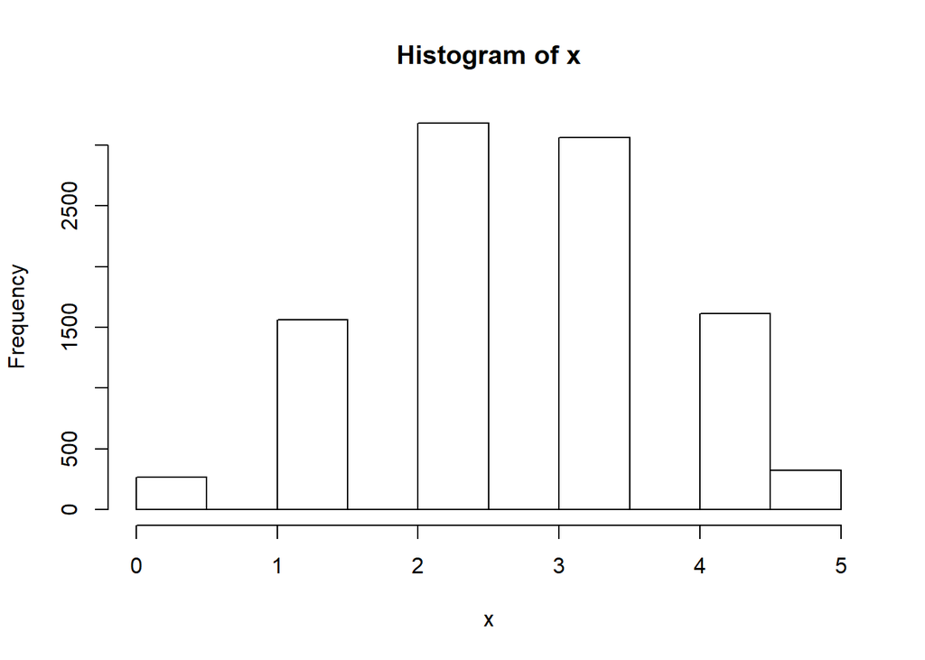

```r
hist(x, right = FALSE)
```

4. Create a new variable y, that stores information about 10 random tosses.

```r
y = rbinom(10, 5, 0.5)
```

5. Create a histogram for y using hist() function

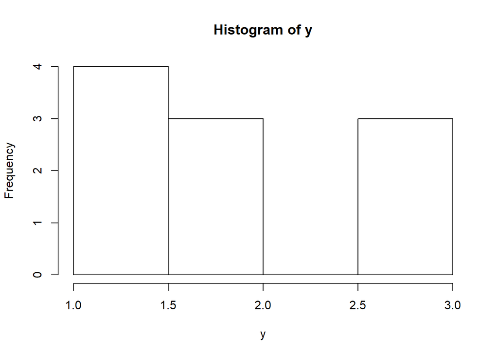

```r
hist(y)
```

6. Repeat the steps from 2 to 5. What are the differences you can observe in these histograms?
7. Investigate the dbinom() function to find the probability of getting at least 4 heads. (Hint : you will need to run this command several times and sum. #Here we are using y as our case, size = 10 tosses.

```r
vprob = dbinom(c(1,2,3,4), 10, .5) # 10 is the number of tosses. the dbinom gives the probability of x = 1 (one head in 10 tosses) where prob of head is 0.5, then the probability of x = 2 (two heads in 10 tosses), etc.

# We will add this vector of probabilities, vprob, to find the probability of getting at least 4 heads.

sum(vprob)
```

```
## [1] 0.3759766
```

```r
vprob = dbinom(c(1,2,3,4), 5, 0.5) # 5 is the number of tosses. the dbinom gives the probability of x = 1 (one head in 5 tosses) where prob of head is 0.5, then the probability of x = 2 (two heads in 5 tosses), etc.

# We will add this vector of probabilities, vprob, to find the probability of getting at least 4 heads.

sum(vprob)
```

```
## [1] 0.9375
```

```r
# can do the same thing with the pbinom function. Its its CDF.
```

Question 1b: Find the probability of getting at least four heads out of 5 tosses using the rbinom() function.

Steps :

1. Use rbinom() to generate a simulation of 10,000 varieties and store the results in variable x.

```r
x = rbinom(10000, 5, 0.5)
```

2. Use the mean() function to estimate at least four heads.

```r
rbinom(1, 5, 0.5)
```

```
## [1] 4
```

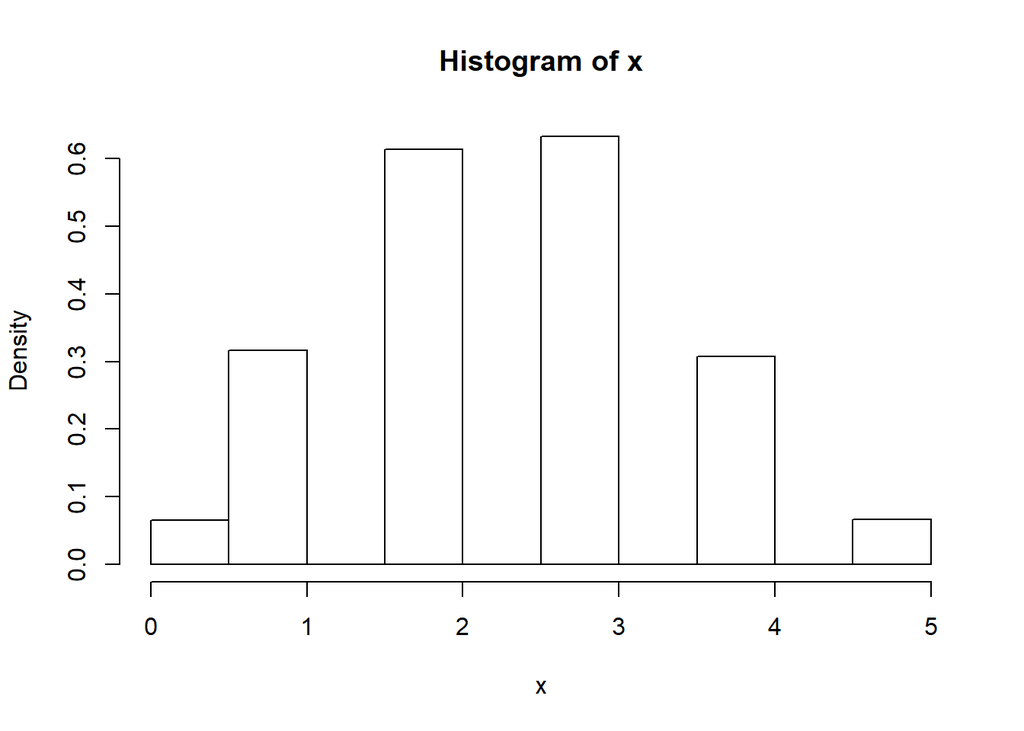

```r
hist(x, freq = F)
```

```r
mean(x)
```

```
## [1] 2.4999
```

Question 2: What is the probability of having 2 successes for a random variable X with a distribution of Binomial(6, 1/3).

• Binomial(n,p) corresponds to a binomial distribution with n independent Bernoulli trials where probability of success is p.

```r
dbinom(x=2, size = 6, prob = 1/3, log = FALSE)
```

```
## [1] 0.3292181
```

• Investigate the dbinom() function and check all the possible arguments using R’s help function.

```r
?dbinom()
```

• Investigate the function choose() try to calculate the same probability using the choose function.

```r
choose(6, 2)*((1/3)^2)*((2/3)^(6-2))
```

```
## [1] 0.3292181
```

Question 3: Compute the whole sample space for a random variable X with a distribution of Binomial(9, 3/4).

```r
# sample space is the possible values r.v X can take. If X ~ Bin(9,3/4) then it can take values x = 0, 1, 2, 3, 4, 5, 6, 7, 8, 9.
```

• Investigate the dbinom() function and check all the possible arguments using R’s help function.

Question 4: For a disease known to have a complication frequency of 20%, a surgeon suggests a new procedure. He tests it on 10 patients and there are no complications. What is the probability of operating on 10 patients successfully with the traditional method?

```r
dbinom(x=10, size = 10, prob = .20, log = FALSE)
```

```
## [1] 1.024e-07
```

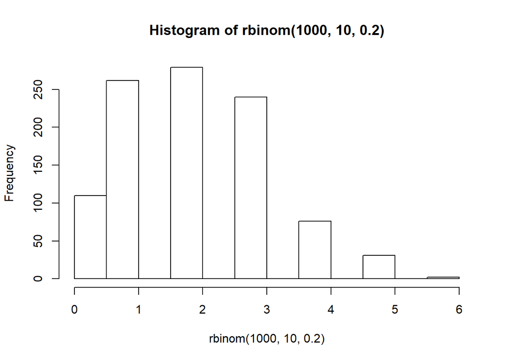

```r
#informative:
hist(rbinom(1000, 10, .2), freq = T)
```

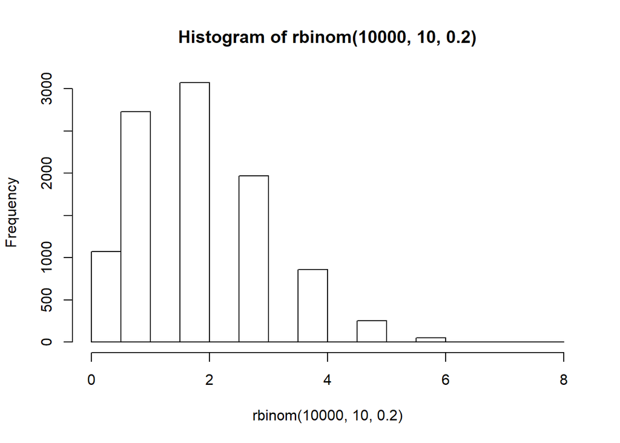

```r
hist(rbinom(10000, 10, .2), freq = T)
```

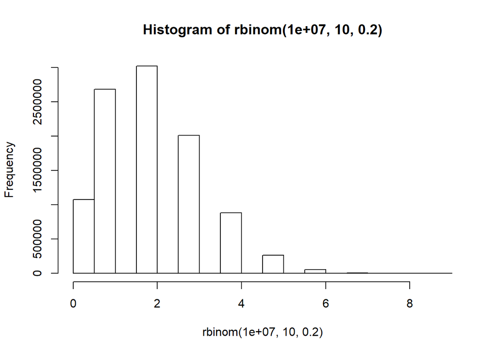

```r
hist(rbinom(10000000, 10, .2), freq = T)
```

Question 5: Suppose there are twelve multiple choice questions in an English class quiz. Each question has five possible answers, and only one of them is correct. Find the probability of having four or less correct answers if a student attempts to answer every question at random.

• Investigate the pbinom() function and check all the possible arguments using R help

```r
pbinom(4, 12, 1/5) # number of trials = 12, num of success = 4, probofsuccess = 1/5
```

```
## [1] 0.9274445
```

Exercise 2: The Poisson distribution in R Question 1: If there are twelve cars crossing a bridge per minute on average, find the probability of having seventeen or more cars crossing the bridge in a particular minute.  
Steps :

1. Investigate the ppois() distribution function using R’s help function.

```r
?ppois()
```

2. From the question decide the right values to be set for x and lambda and the lower.tail

```r
# This is the probability of 17 or less cars crossing in a min.
ppois(17, 12)
```

```
## [1] 0.9370337
```

```r
# This is the probability of 17 or more cars crossing in a min.
1 - ppois(17, 12) # or equivalently ppois(17, 12, lower.tail = F)
```

```
## [1] 0.0629663
```

3. Calculate the probability of having sixteen or less cars crossing the bridge in a particular minute.

```r
ppois(16, 12, lower.tail = T)
```

```
## [1] 0.898709
```

Exercise 3: The Hypergeometric distribution in R

We are working at a forest conservation agency and our task is to tag a population of endangered deer to prevent illegal hunting. We know that the forest has approximately 400 deer. Last week, we have captured 100 of the deer and tagged, and released them into the wild. This week we have captured 125 deer. What is the probability that we have captured 30 deer that were captured last week. (Assume that the recaptured deer are equally likely to be caught and they do not learn to avoid humans)

• You can either use the formula from videos or dhyper() function (takes 4 values)

```r
#white balls picked = 30, total white balls = 100, total black b= 300, samplesize=125
?dhyper(30, 100, 300, 125)

dhyper(30, 100, 300, 125)
```

```
## [1] 0.09507884
```